# Supervised learning with caret

## Pre-process Data: Normalization

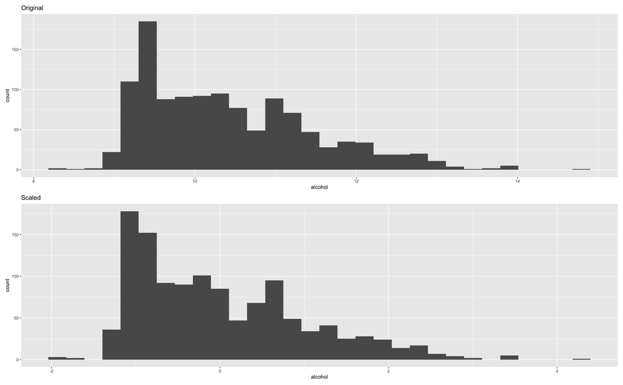

## Tune model hyperparameters with cross-validation

- Used to select best combination of predictors and model parameters
- Estimates model performance (e.g., AUC or r-square) for each candidate model
- Uses a random subset of the training data to train the model and a withheld subset to test
- Select cross validation method: 10-fold repeated cross validation is common
- Define hyperparameter selection method: grid search is the simplest approach
- Define summary measures
- `trainControl` command specifies all these parameters in a single statement

## Define training parameters: `trainControl`

```r
train.control = trainControl(method = "repeatedcv",
                              number = 10, repeats = 3, # number: number of folds
                              search = "grid", # for tuning hyperparameters
                              classProbs = TRUE, # return probability of prediction
                              savePredictions = "final",
                              summaryFunction = twoClassSummary
                             )
```

## Select models to train

– Over 200 different models from 50 categories (e.g., Linear regression, boosting, bagging, cost-sensitive learning)

- List of models: http://caret.r-forge.r-project.org/modelList.html
- The `train` statement can train any of them
- Here we select three:
  - Logistic regression
  - Support vector machine
  - xgboost, a boosted random forest that performs well in many situations

## Train models and tune hyperparameters with the `train` function

- Specify class and predictor variables
- Specify one of the over 200 models (e.g., xgboost)
- Specify the metric, such as ROC
- Include the `train.control` object specified earlier

Train models and tune hyperparameters: Logistic regression

- Logistic regression has no tuning parameters
- 10-fold repeated (3 times) cross-validation occurs once
- Produces a total of 30 instances of model fitting and testing
- Cross validation provides a nearly unbiased estimate of the performance of the model on the held out data

```r
glm.fit = train(x = trainScaled, y = trainClass,
   method = 'glm', metric = "ROC",
   trControl = train.control)

glm.fit
```

```
Generalized Linear Model

1200 samples
  11 predictor
   2 classes: 'bad', 'good'

No pre-processing
Resampling: Cross-Validated (10 fold, repeated 3 times)
Summary of sample sizes: 1080, 1080, 1080, 1080, 1079, 1080, ...
Resampling results:

  ROC        Sens       Spec
  0.8164842  0.7204004  0.7576042
```

## Train models and tune hyperparameters: Support vector machine

- Linear support vector machines have a single tuning parameter–C
- C (Cost)
- C = 1000 “hard margin” tends to be sensitive to individual data points and is prone to over fitting

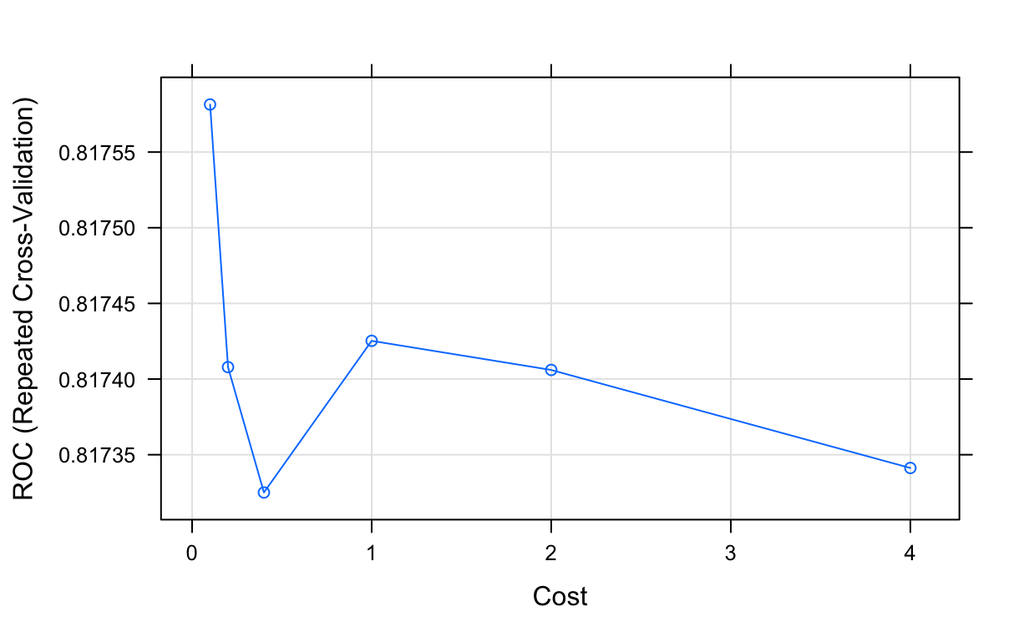

```r
grid = expand.grid(C = c(.1, .2, .4, 1, 2, 4))
svm.fit =  train(x = trainScaled, y = trainClass,
  method = "svmLinear", metric = "ROC",
  tuneGrid = grid, # Overrides tuneLength
  tuneLength = 3, # Number of levels of each hyper parameter, unless specified by grid
  trControl = train.control, scaled = TRUE)

plot(svm.fit)
```

## Train model and tune hyperparameters: xgboost

Classification depends on adding outcomes across many trees

Trees are built in sequence to address the errors (residuals) of the previous trees

- Hyperparameters of xgboost
- nrounds (# Boosting Iterations)–model robustness
- max_depth (Max Tree Depth)–model complexity
- eta (Shrinkage)–model robustness
- gamma (Minimum Loss Reduction)–model complexity
- colsample_bytree (Subsample Ratio of Columns)–model robustness
- min_child_weight (Minimum Sum of Instance Weight)–model complexity
- subsample (Subsample Percentage)–model robustness

**A grid search with 3 levels for each parameter produces 3^7 combinations!**

`tuneLength = 3` produces

```
- nrounds (# Boosting Iterations) (50 100 150)

- max_depth (Max Tree Depth) (1, 2, 3)

- eta (Shrinkage) (.3, .4)

- gamma (Minimum Loss Reduction) (0)

- colsample_bytree (Subsample Ratio of Columns) (.6, .8)

- min_child_weight (Minimum Sum of Instance Weight) (1)

- subsample (Subsample Percentage) (.50, .75, 1.0)
```

– 108 different model combinations each trained and tested 10X3 times

```r
xgb.fit = train(x = trainScaled, y = trainClass,
  method = "xgbTree", metric = "ROC",
  tuneLength = 3, # Depends on number of parameters in algorithm
  trControl = train.control, scaled = TRUE)
```

## Assess performance: Confusion matrix (glm)

Use trained model to predict on the4 unseen test data

```r
glm.pred = predict(glm.fit, testScaled)

confusionMatrix(glm.pred, testClass)
```

```
Confusion Matrix and Statistics

          Reference
Prediction bad good
      bad  132   63
      good  54  150

               Accuracy : 0.7068
                 95% CI : (0.6594, 0.751)
    No Information Rate : 0.5338
    P-Value [Acc > NIR] : 1.272e-12

                  Kappa : 0.4126

 Mcnemar's Test P-Value : 0.4595

            Sensitivity : 0.7097
            Specificity : 0.7042
         Pos Pred Value : 0.6769
         Neg Pred Value : 0.7353
             Prevalence : 0.4662
         Detection Rate : 0.3308
   Detection Prevalence : 0.4887
      Balanced Accuracy : 0.7070

       'Positive' Class : bad
```

## Assess performance: Confusion matrix (svm)

```r
svm.pred = predict(svm.fit, testScaled)

confusionMatrix(svm.pred, testClass$goodwine)
```

```
Confusion Matrix and Statistics

          Reference
Prediction bad good
      bad  139   59
      good  47  154

               Accuracy : 0.7343
                 95% CI : (0.6881, 0.777)
    No Information Rate : 0.5338
    P-Value [Acc > NIR] : <2e-16

                  Kappa : 0.4684

 Mcnemar's Test P-Value : 0.2853

            Sensitivity : 0.7473
            Specificity : 0.7230
         Pos Pred Value : 0.7020
         Neg Pred Value : 0.7662
             Prevalence : 0.4662
         Detection Rate : 0.3484
   Detection Prevalence : 0.4962
      Balanced Accuracy : 0.7352

       'Positive' Class : bad
```

## Assess Performance: Confusion matrix (xgb)

```r
xgb.pred = predict(xgb.fit, testScaled)

confusionMatrix(xgb.pred, testClass$goodwine)
```

```
Confusion Matrix and Statistics

          Reference
Prediction bad good
      bad  148   53
      good  38  160

               Accuracy : 0.7719
                 95% CI : (0.7276, 0.8122)
    No Information Rate : 0.5338
    P-Value [Acc > NIR] : <2e-16

                  Kappa : 0.5441

 Mcnemar's Test P-Value : 0.1422

            Sensitivity : 0.7957
            Specificity : 0.7512
         Pos Pred Value : 0.7363
         Neg Pred Value : 0.8081
             Prevalence : 0.4662
         Detection Rate : 0.3709
   Detection Prevalence : 0.5038
      Balanced Accuracy : 0.7734

       'Positive' Class : bad
```

## Compare models

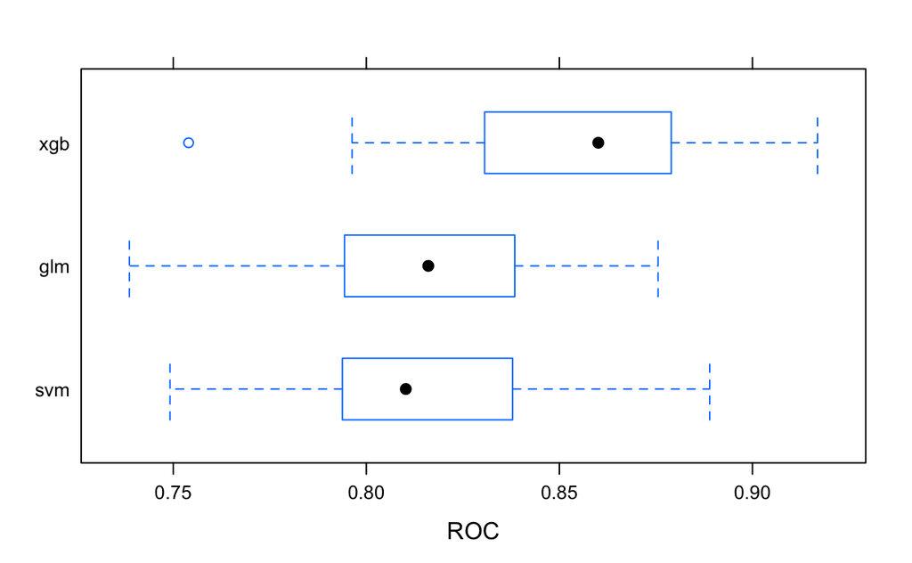

```r
mod.resamps = resamples(list(glm = glm.fit, svm = svm.fit, xgb = xgb.fit))

# dotplot(mod.resamps, metric="ROC")

bwplot(mod.resamps, metric = "ROC")
```

```r
NA
NA
```

## Assess performance (xgb): ROC plot

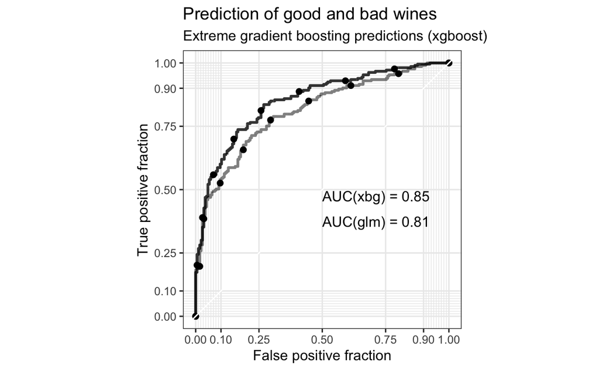

## xgboost predictions

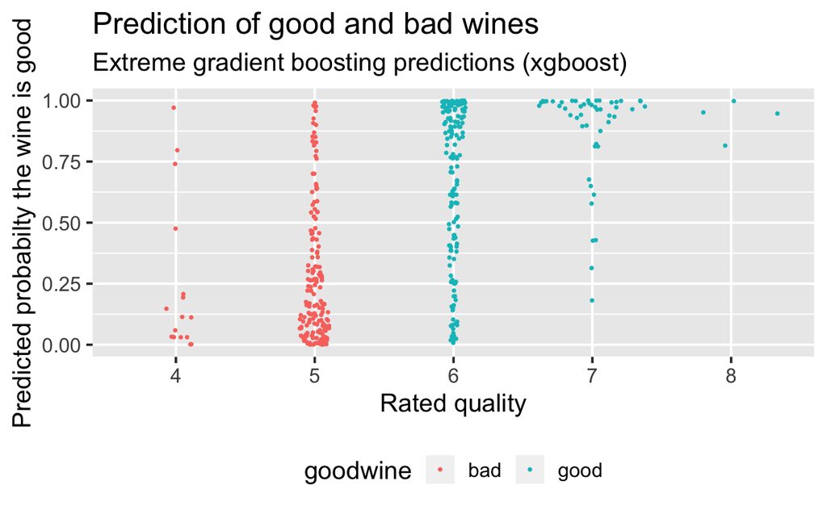